# Predicting PH

Jack Wright, Richard Zheng, Mario Pena

4/29/2022

## Load Packages

```r
library(tidytext)
library(tidyverse)
library(readxl)
library(openxlsx)
library(finetune)
library(visdat)
library(naniar)
library(tidymodels)
library(janitor)
library(psych)
library(car)
library(caret)
```

## Load files

```r
train_data<-openxlsx::read.xlsx('https://github.com/JackJosephWright/predicting_ph/blob/main/data/StudentData.xlsx?raw=true', sep.names=' ')

test_data = openxlsx::read.xlsx('https://github.com/JackJosephWright/predicting_ph/blob/main/data/StudentEvaluation.xlsx?raw=true', sep.names=' ')

train_data%>%head()
```

```
##   Brand Code Carb Volume Fill Ounces PC Volume Carb Pressure Carb Temp   PSC
## 1          B    5.340000    23.96667 0.2633333          68.2     141.2 0.104
## 2          A    5.426667    24.00667 0.2386667          68.4     139.6 0.124
## 3          B    5.286667    24.06000 0.2633333          70.8     144.8 0.090
## 4          A    5.440000    24.00667 0.2933333          63.0     132.6    NA
## 5          A    5.486667    24.31333 0.1113333          67.2     136.8 0.026
## 6          A    5.380000    23.92667 0.2693333          66.6     138.4 0.090
##   PSC Fill PSC CO2 Mnf Flow Carb Pressure1 Fill Pressure Hyd Pressure1
## 1     0.26    0.04     -100          118.8          46.0             0
## 2     0.22    0.04     -100          121.6          46.0             0
## 3     0.34    0.16     -100          120.2          46.0             0
## 4     0.42    0.04     -100          115.2          46.4             0
## 5     0.16    0.12     -100          118.4          45.8             0
## 6     0.24    0.04     -100          119.6          45.6             0
##   Hyd Pressure2 Hyd Pressure3 Hyd Pressure4 Filler Level Filler Speed
```

[output cut: 27 more lines]

## Missing Data

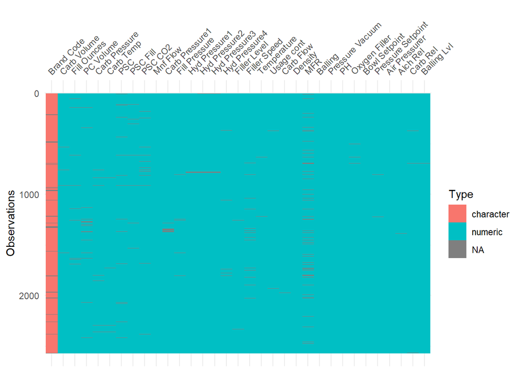

```r
vis_dat(train_data)
```

The missing data does not look random. Lets take a closer look at how the missing data is distributed

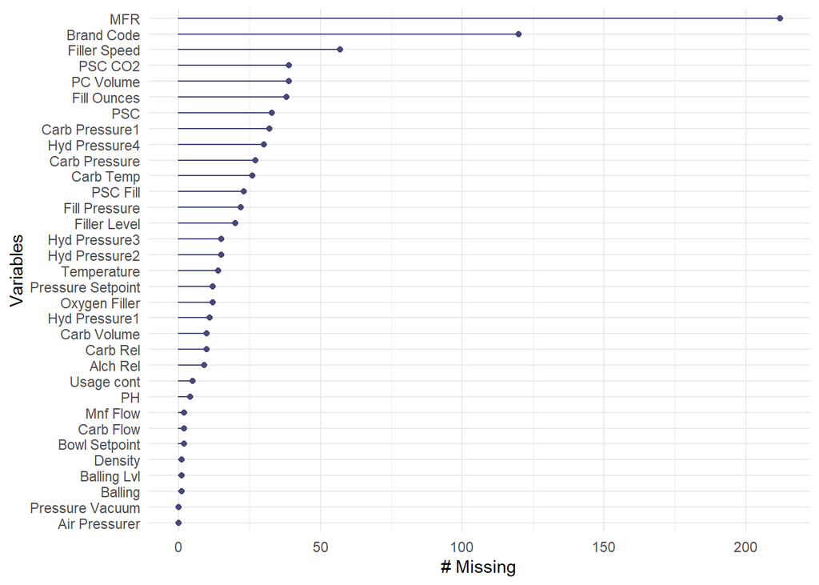

```r
gg_miss_var(train_data)
```

Little’s Missing Completely at Random test will give us some insight if there are patterns in the missing data.

```r
mcar_test(train_data)
```

```
## # A tibble: 1 x 4
##   statistic    df p.value missing.patterns
##       <dbl> <dbl>   <dbl>            <int>
## 1     7507.  3451       0              115
```

With a high test statistic and low p-value we can conclude that there is structure to the missing data.

```r
mcar_test(train_data%>%select(-c(MFR,`Brand Code`,`Filler Speed`)))
```

```
## # A tibble: 1 x 4
##   statistic    df p.value missing.patterns
##       <dbl> <dbl>   <dbl>            <int>
## 1     6377.  2012       0               74
```

We can conclude that there is some structure to the missing data

## MFR Missing Data

```r
cor(train_data%>%select(-`Brand Code`)%>%na.omit())%>%as.data.frame()%>%arrange(desc(MFR))%>%select(MFR)%>%head()
```

```
##                        MFR
## MFR             1.00000000
## Filler Speed    0.95142239
## Filler Level    0.06405259
## Balling         0.05382864
## Pressure Vacuum 0.05159662
## Hyd Pressure2   0.04521297
```

Our most missing predictor `MFR` has a 95% correlation with `Filler Speed`.

```r
train_data%>%
  mutate(both_miss = case_when(
    (is.na(MFR) & is.na(`Filler Speed`) )~TRUE,
         TRUE~FALSE)
  )%>%
  summarize("both missing" = sum(both_miss), 'MFR missing' = sum(is.na(`Filler Speed`)))
```

```
##   both missing MFR missing
## 1           54          57
```

94% of the time when `Filler Speed` is missing, `MFR` is also missing. The best option is to drop MFR and listwise delete the missing values from `Filler Speed`

## Missing Data in `Brand Code`

```r
cat_impute_df<-train_data%>%na.omit()%>%select(-c(MFR, PH))%>%mutate(`Brand Code` = as.factor(`Brand Code`))
brand_split<-split

code_count<-
  cat_impute_df%>%
  count(`Brand Code`)

code_count
```

```
##   Brand Code    n
## 1          A  224
## 2          B 1050
## 3          C  252
## 4          D  512
```

```r
cat_impute_df<-clean_names(cat_impute_df)
brand_split<-initial_split(cat_impute_df)
brand_train<-training(brand_split)
brand_test<-testing(brand_split)
```

Note that there is a class imbalance in the Brand Codes so it is important to stratify before predicting

```r
tree_spec<-decision_tree()%>%
  set_engine('rpart')%>%
  set_mode('classification')
tune_spec<-
  decision_tree(
    cost_complexity = tune(),
    tree_depth = tune()
  )%>%
  set_engine("rpart") %>%
  set_mode("classification")
tree_grid<- grid_regular(cost_complexity(),
                         tree_depth(),
                         levels = 5)
brand_folds<-vfold_cv(brand_train , v = 10)
brand_folds
```

```
## #  10-fold cross-validation
## # A tibble: 10 x 2
##    splits             id
##    <list>             <chr>
##  1 <split [1375/153]> Fold01
##  2 <split [1375/153]> Fold02
##  3 <split [1375/153]> Fold03
##  4 <split [1375/153]> Fold04
##  5 <split [1375/153]> Fold05
##  6 <split [1375/153]> Fold06
##  7 <split [1375/153]> Fold07
##  8 <split [1375/153]> Fold08
##  9 <split [1376/152]> Fold09
## 10 <split [1376/152]> Fold10
```

```r
set.seed(123)
tree_wf<-workflow()%>%
  add_model(tune_spec)%>%
  add_formula(brand_code~.)
```

```r
tree_res<-
  tree_wf%>%
  tune_grid(
    resamples = brand_folds,
    grid = tree_grid
  )
```

```r
best_tree<-tree_res%>%
  select_best('accuracy')

final_wf<-
  tree_wf%>%
  finalize_workflow(best_tree)
```

```r
final_fit<-
  final_wf%>%
  last_fit(brand_split)
final_fit%>%
  collect_metrics()
```

```
## # A tibble: 2 x 4
##   .metric  .estimator .estimate .config
##   <chr>    <chr>          <dbl> <chr>
## 1 accuracy multiclass     0.941 Preprocessor1_Model1
## 2 roc_auc  hand_till      0.967 Preprocessor1_Model1
```

`Brand Code` can be predicted with a high accuracy using the other predictors. It would be advisable to impute the missing `Brand Code` before modeling.

## Data Structure

```r
glimpse(train_data)
```

```
## Rows: 2,571
## Columns: 33
## $ `Brand Code`        <chr> "B", "A", "B", "A", "A", "A", "A", "B", "B", "B", ~
## $ `Carb Volume`       <dbl> 5.340000, 5.426667, 5.286667, 5.440000, 5.486667, ~
## $ `Fill Ounces`       <dbl> 23.96667, 24.00667, 24.06000, 24.00667, 24.31333, ~
## $ `PC Volume`         <dbl> 0.2633333, 0.2386667, 0.2633333, 0.2933333, 0.1113~
## $ `Carb Pressure`     <dbl> 68.2, 68.4, 70.8, 63.0, 67.2, 66.6, 64.2, 67.6, 64~
## $ `Carb Temp`         <dbl> 141.2, 139.6, 144.8, 132.6, 136.8, 138.4, 136.8, 1~
## $ PSC                 <dbl> 0.104, 0.124, 0.090, NA, 0.026, 0.090, 0.128, 0.15~
## $ `PSC Fill`          <dbl> 0.26, 0.22, 0.34, 0.42, 0.16, 0.24, 0.40, 0.34, 0.~
## $ `PSC CO2`           <dbl> 0.04, 0.04, 0.16, 0.04, 0.12, 0.04, 0.04, 0.04, 0.~
## $ `Mnf Flow`          <dbl> -100, -100, -100, -100, -100, -100, -100, -100, -1~
## $ `Carb Pressure1`    <dbl> 118.8, 121.6, 120.2, 115.2, 118.4, 119.6, 122.2, 1~
## $ `Fill Pressure`     <dbl> 46.0, 46.0, 46.0, 46.4, 45.8, 45.6, 51.8, 46.8, 46~
## $ `Hyd Pressure1`     <dbl> 0, 0, 0, 0, 0, 0, 0, 0, 0, 0, 0, 0, 0, 0, 0, 0, 0,~
```

[output cut: 20 more lines]

There are 2571 observations of 32 predictors and the response (PH). All data are continuous besides the “Brand Code” which is unordered Categorical.

## Exploring the Response

```r
train_data<-train_data%>%na.omit()
train_data%>%na.omit()%>%summarize(mean = mean(PH), "standard deviation" = sd(PH))
```

```
##       mean standard deviation
## 1 8.552669          0.1707606
```

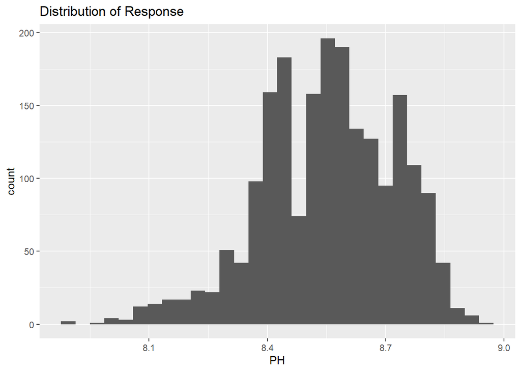

```r
ggplot(train_data, aes(x = PH))+geom_histogram()+ggtitle('Distribution of Response')
```

## Exploring the predictors

```r
description<-psych::describe(train_data)
```

## Normality

```r
description%>%
  filter((abs(skew)>=.5))%>%nrow()
```

```
## [1] 21
```

```r
skew_list<-as.list(description%>%
  filter((abs(skew)>=.5))%>%rownames())
```

skewed predictors can be found in the list `skew_list`

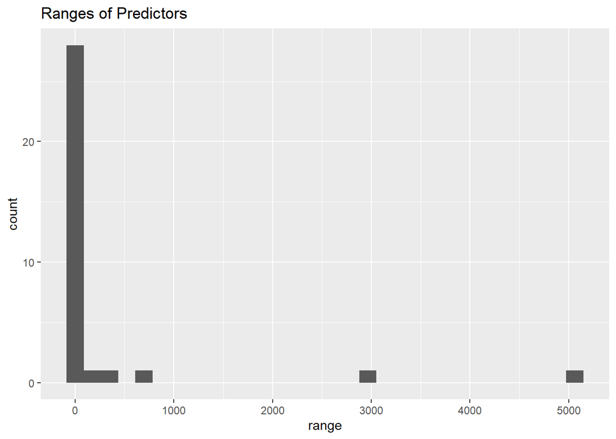

```r
ggplot(description, aes(x=range))+geom_histogram()+ggtitle('Ranges of Predictors')
```

Most of the predictors range is 1, but a minority are much larger. Depending on the model this data will need to be `centered` and `scaled`

## Highly Correlated Predictor Pairs

```r
correlated_predictors<-findCorrelation(cor(train_data%>%select(-'Brand Code')), names = TRUE)
correlated_predictors
```

```
## [1] "Balling"       "Hyd Pressure3" "Alch Rel"      "Balling Lvl"
## [5] "Bowl Setpoint" "Filler Speed"
```

There are 6 highly correlated predictors and can be found in the `correlated_predictors` list

## PCA

```r
pca_rec<-recipe(~., train_data%>%select(-'Brand Code'))%>%
  update_role(PH, new_role = 'id')%>%
  step_normalize(all_predictors())%>%
  step_pca(all_predictors())
pca_prep<-prep(pca_rec)
```

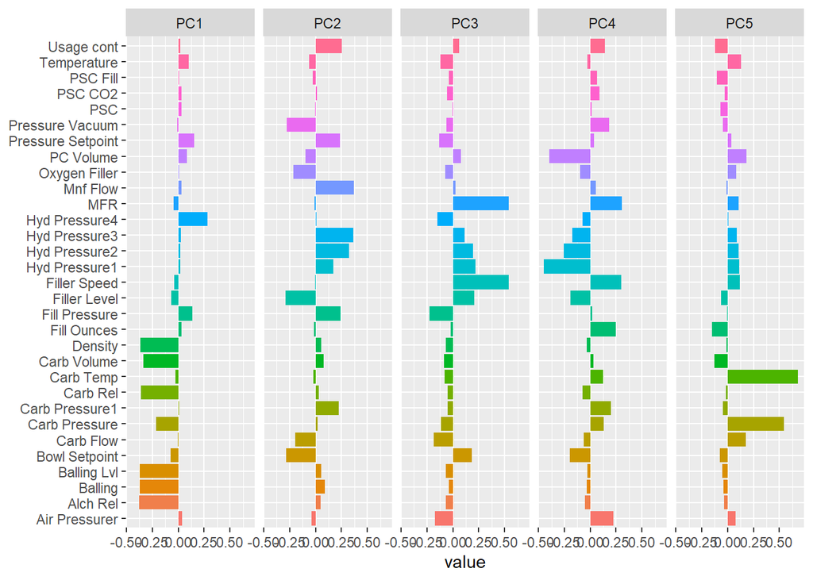

```r
tidied_pca<-tidy(pca_prep, 2)

#error here component does not exist
tidied_pca%>%
  filter(component %in% paste0('PC', 1:5))%>%
  mutate(component = fct_inorder(component))%>%
  ggplot(aes(value,terms,fill = terms))+
  geom_col(show.legend = FALSE)+
  facet_wrap(~component,nrow=1)+
  labs(y = NULL)
```

```r
summary(prcomp(train_data%>%select(-`Brand Code`), scale = TRUE))
```

```
## Importance of components:
##                           PC1    PC2     PC3     PC4     PC5     PC6     PC7
## Standard deviation     2.5555 2.4508 1.48330 1.47574 1.31191 1.24571 1.15438
## Proportion of Variance 0.2041 0.1877 0.06876 0.06806 0.05378 0.04849 0.04164
## Cumulative Proportion  0.2041 0.3918 0.46053 0.52859 0.58237 0.63087 0.67251
##                            PC8     PC9    PC10    PC11    PC12    PC13    PC14
## Standard deviation     1.05272 1.01942 0.99613 0.93879 0.90755 0.88793 0.85451
## Proportion of Variance 0.03463 0.03248 0.03101 0.02754 0.02574 0.02464 0.02282
## Cumulative Proportion  0.70714 0.73962 0.77063 0.79817 0.82391 0.84855 0.87136
##                           PC15   PC16   PC17    PC18    PC19    PC20    PC21
## Standard deviation     0.81951 0.7652 0.7066 0.67666 0.66979 0.58281 0.52245
## Proportion of Variance 0.02099 0.0183 0.0156 0.01431 0.01402 0.01061 0.00853
## Cumulative Proportion  0.89235 0.9106 0.9263 0.94056 0.95458 0.96519 0.97372
##                           PC22    PC23    PC24   PC25   PC26    PC27    PC28
## Standard deviation     0.43970 0.40154 0.39113 0.3297 0.2655 0.22208 0.19871
## Proportion of Variance 0.00604 0.00504 0.00478 0.0034 0.0022 0.00154 0.00123
## Cumulative Proportion  0.97976 0.98480 0.98958 0.9930 0.9952 0.99672 0.99796
##                           PC29    PC30    PC31    PC32
## Standard deviation     0.17726 0.14081 0.10490 0.05591
## Proportion of Variance 0.00098 0.00062 0.00034 0.00010
## Cumulative Proportion  0.99894 0.99956 0.99990 1.00000
```

Looking at the percent of variance explained, we want to limit the total number of principle components used while maintaining a high amount of variance explained, so we will set the threshold for modeling to 90%.

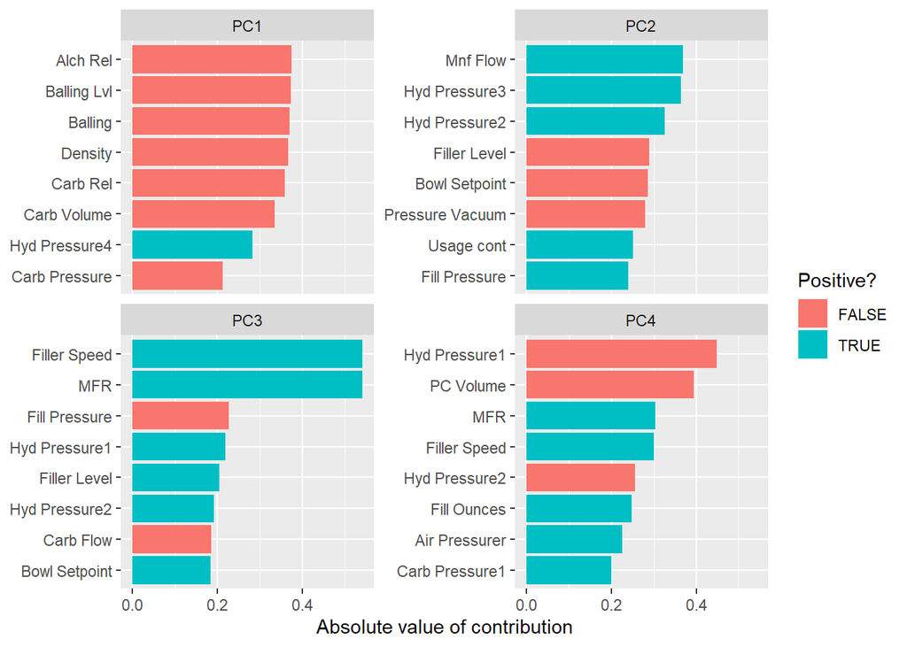

```r
tidied_pca %>%
  filter(component %in% paste0("PC", 1:4)) %>%
  group_by(component) %>%
  top_n(8, abs(value)) %>%
  ungroup() %>%
  mutate(terms = reorder_within(terms, abs(value), component)) %>%
  ggplot(aes(abs(value), terms, fill = value > 0)) +
  geom_col() +
  facet_wrap(~component, scales = "free_y") +
  scale_y_reordered() +
  labs(
    x = "Absolute value of contribution",
    y = NULL, fill = "Positive?"
  )
```

Now lets look at how these features are distributed in the plane of the first two Principle Components

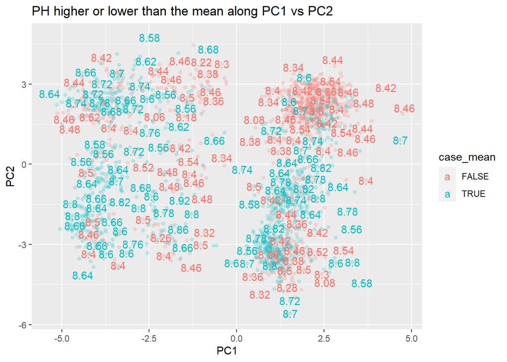

```r
temp<-juice(pca_prep)%>%mutate(case_mean = case_when(PH > mean(PH)~TRUE, TRUE ~FALSE))
temp%>%
  ggplot(aes(PC1,PC2, label = PH, color = case_mean))+
  geom_point(alpha = .2)+
  geom_text(check_overlap = TRUE, family = 'IBMlexSans')+
  ggtitle('PH higher or lower than the mean along PC1 vs PC2')
```

There does seem to be some grouping in the PC1 vs PC2 plane, we could try some sort of `radial SVM` to model this.

## Methodology

Since the response variable is continuous, we will use a series of regression models as candidates. We will train a random forest and XGboost because they have proven historically to be excellent at modeling continuous variables. Our EDA pointed us towards some potential clustering in the principle components, so we will train a radial SVM. Our EDA didn’t point us towards any terribly strong linear correlations, and the potential clustering from the EDA makes us want to throw in a KNN model just to be safe.

## Data Preparation

From the *Missing Data* section, we have decided to drop `MFR` and listwise delete observations for `Filler Speed`. Some preliminary modeling showed that `Brand Code` was very responsive to imputation as well. Since the dataset is fairly large and the remaining datapoints seem missing at random, we will drop the remaining observations with missing data.

Our EDA showed that a large number of the predictors were skewed, so we will center and scale the data for models that do not handle skew data or unscaled predictors well, like KNN or SVM. For the ensemble method, we will leave the data as is.

## Partitioning the Data

```r
#removing MFR
train_data<-train_data%>%select(-MFR)%>%mutate(`Brand Code` = as.factor(`Brand Code`))
train_data<-train_data%>%clean_names()
test_data<-test_data%>%select(-MFR)
test_data<-test_data%>%clean_names()
ph_split<-initial_split(train_data%>%na.omit())
ph_train<-training(ph_split)
ph_test<-testing(ph_split)
```

## Data Preprocessing

```r
# create base recipe with missing data handling
base_rec<-
  recipe(ph~., data = ph_train)%>%
  #imputing brand code

  step_impute_bag(brand_code)%>%
  step_unknown(brand_code)%>%
  step_dummy(brand_code)%>%
  step_impute_bag(all_predictors())
  #omitting remaining missing data
  #step_naomit(all_predictors())
temp<-juice(prep(base_rec))
# create centered and scaled data
cs_rec<-
  base_rec%>%
  step_center%>%
  step_scale()
pca_rec<-
  base_rec%>%
  step_pca(threshold = .90)

#create resamples
ph_folds<-vfold_cv(ph_train,v = 5)
```

## Create Models for Tuning

```r
svm_r_spec<-
svm_rbf(cost = tune(), rbf_sigma = tune())%>%
  set_engine('kernlab')%>%
  set_mode('regression')
knn_spec<-
  nearest_neighbor(neighbors = tune(), dist_power = tune(), weight_func = tune())%>%
  set_engine('kknn')%>%
  set_mode('regression')
boost_spec<-
  boost_tree(mtry = tune(), min_n = tune(), trees = 100)%>%
  set_mode('regression')
rf_spec<-
  rand_forest(mtry = tune(), min_n = tune(), trees = 100)%>%
  set_engine('ranger', importance = 'impurity')%>%
  set_mode('regression')
```

## Create the workflow set

```r
cc<-
  workflow_set(
    preproc = list(center_scale = cs_rec),
    models  = list(SVM_radial = svm_r_spec, knn_spec)
  )
no_pre_proc<-
  workflow_set(
    preproc = list(base = base_rec),
    models = list(boost = boost_spec, rf = rf_spec)
  )
pca_proc<-
  workflow_set(
    preproc = list(pca = pca_rec),
    models = list(svm_pca = svm_r_spec , boost_pca = boost_spec , rf_pca = rf_spec , knn_pca = knn_spec)
  )
all_workflows<-
  bind_rows(no_pre_proc, cc)%>%
  mutate(wflow_id = gsub('(center_scale_)|(base_)|(pca_)', '',wflow_id))
```

## Tuning and Evaluating

We will use a racing method to tune the models. This will help us limit the overall computational burden by removing candidate tuning parameters quickly, therefore reducing the total amount of tuned models.

```r
race_ctrl<-
  control_race(
    save_pred = TRUE,
    parallel_over = 'everything',
    save_workflow = TRUE
  )
race_results_time<-
  system.time(
    race_results<-
      all_workflows%>%
      workflow_map(
        'tune_race_anova',
        seed = 123,
        resamples = ph_folds,
        control = race_ctrl,
        verbose = TRUE
      )
  )
```

```
## i 1 of 4 tuning:     boost
```

```
## i Creating pre-processing data to finalize unknown parameter: mtry
```

```
## v 1 of 4 tuning:     boost (15m 36.2s)
```

```
## i 2 of 4 tuning:     rf
```

```
## i Creating pre-processing data to finalize unknown parameter: mtry
```

```
## v 2 of 4 tuning:     rf (12m 47.8s)
```

```
## i 3 of 4 tuning:     SVM_radial
```

[output not shown]

[output not shown]

[output not shown]

[output not shown]

[output not shown]

[output not shown]

[output not shown]

[output not shown]

[output not shown]

[output not shown]

[output not shown]

[output not shown]

[output not shown]

[output not shown]

[output not shown]

[output not shown]

[output not shown]

[output not shown]

[output not shown]

[output not shown]

[output not shown]

[output not shown]

[output not shown]

[output not shown]

[output not shown]

[output not shown]

[output not shown]

[output not shown]

[output not shown]

[output not shown]

[output not shown]

[output not shown]

```
## v 3 of 4 tuning:     SVM_radial (8m 46.6s)
```

```
## i 4 of 4 tuning:     nearest_neighbor
```

```
## v 4 of 4 tuning:     nearest_neighbor (13m 4.6s)
```

```r
race_results
```

```
## # A workflow set/tibble: 4 x 4
##   wflow_id         info             option    result
##   <chr>            <list>           <list>    <list>
## 1 boost            <tibble [1 x 4]> <opts[2]> <race[+]>
## 2 rf               <tibble [1 x 4]> <opts[2]> <race[+]>
## 3 SVM_radial       <tibble [1 x 4]> <opts[2]> <race[+]>
## 4 nearest_neighbor <tibble [1 x 4]> <opts[2]> <race[+]>
```

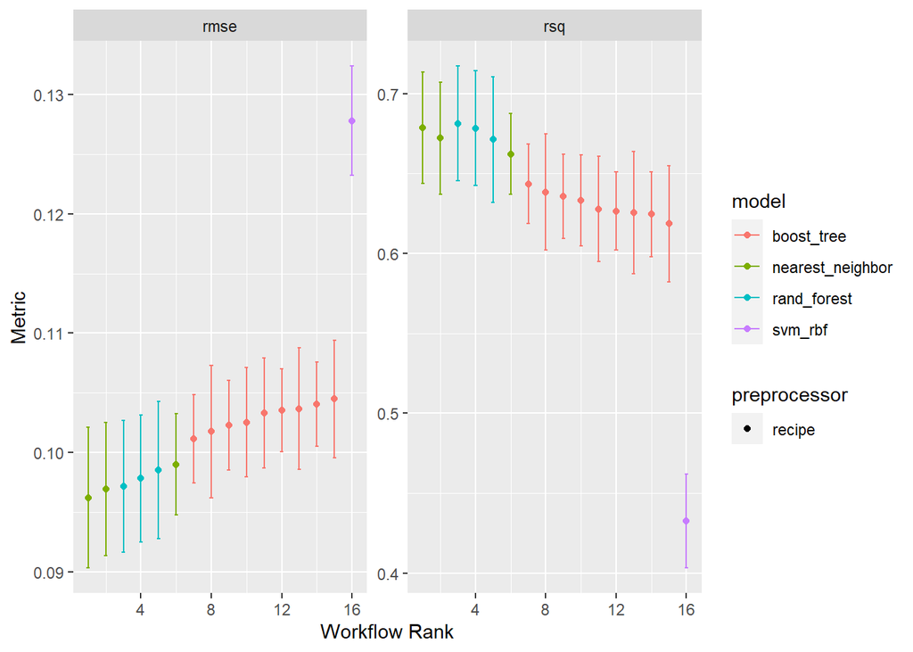

```r
autoplot(race_results)
```

```r
collect_metrics(race_results)
```

```
## # A tibble: 80 x 9
##    wflow_id .config         preproc model .metric .estimator  mean     n std_err
##    <chr>    <chr>           <chr>   <chr> <chr>   <chr>      <dbl> <int>   <dbl>
##  1 boost    Preprocessor1_~ recipe  boos~ rmse    standard   0.105     3 0.00185
##  2 boost    Preprocessor1_~ recipe  boos~ rsq     standard   0.620     3 0.0182
##  3 boost    Preprocessor1_~ recipe  boos~ rmse    standard   0.104     5 0.00299
##  4 boost    Preprocessor1_~ recipe  boos~ rsq     standard   0.619     5 0.0221
##  5 boost    Preprocessor1_~ recipe  boos~ rmse    standard   0.104     5 0.00210
##  6 boost    Preprocessor1_~ recipe  boos~ rsq     standard   0.626     5 0.0149
##  7 boost    Preprocessor1_~ recipe  boos~ rmse    standard   0.103     5 0.00280
##  8 boost    Preprocessor1_~ recipe  boos~ rsq     standard   0.628     5 0.0200
##  9 boost    Preprocessor1_~ recipe  boos~ rmse    standard   0.102     5 0.00338
## 10 boost    Preprocessor1_~ recipe  boos~ rsq     standard   0.638     5 0.0221
## # ... with 70 more rows
```

```r
race_results
```

```
## # A workflow set/tibble: 4 x 4
##   wflow_id         info             option    result
##   <chr>            <list>           <list>    <list>
## 1 boost            <tibble [1 x 4]> <opts[2]> <race[+]>
## 2 rf               <tibble [1 x 4]> <opts[2]> <race[+]>
## 3 SVM_radial       <tibble [1 x 4]> <opts[2]> <race[+]>
## 4 nearest_neighbor <tibble [1 x 4]> <opts[2]> <race[+]>
```

```r
best_results_rf<-
  race_results%>%
  extract_workflow_set_result('rf')%>%
  select_best(metric = 'rmse')
best_results_rf
```

```
## # A tibble: 1 x 3
##    mtry min_n .config
##   <int> <int> <chr>
## 1    21     8 Preprocessor1_Model04
```

```r
best_results_rf<-
  race_results%>%
  extract_workflow_set_result('rf')%>%
  select_best(metric = 'rmse')
rf_test_results<-
  race_results%>%
  extract_workflow('rf')%>%
  finalize_workflow(best_results_rf)%>%
  last_fit(split = ph_split)
collect_metrics(rf_test_results)
```

```
## # A tibble: 2 x 4
##   .metric .estimator .estimate .config
##   <chr>   <chr>          <dbl> <chr>
## 1 rmse    standard       0.103 Preprocessor1_Model1
## 2 rsq     standard       0.664 Preprocessor1_Model1
```

```r
best_results_boost<-
  race_results%>%
  extract_workflow_set_result('boost')%>%
  select_best(metric = 'rmse')
boost_test_results<-
  race_results%>%
  extract_workflow('boost')%>%
  finalize_workflow(best_results_boost)%>%
  last_fit(split = ph_split)
collect_metrics(boost_test_results)
```

```
## # A tibble: 2 x 4
##   .metric .estimator .estimate .config
##   <chr>   <chr>          <dbl> <chr>
## 1 rmse    standard       0.106 Preprocessor1_Model1
## 2 rsq     standard       0.633 Preprocessor1_Model1
```

```r
best_results_knn<-
  race_results%>%
  extract_workflow_set_result('nearest_neighbor')%>%
  select_best(metric = 'rmse')
knn_test_results<-
  race_results%>%
  extract_workflow('nearest_neighbor')%>%
  finalize_workflow(best_results_knn)%>%
  last_fit(split = ph_split)
collect_metrics(knn_test_results)
```

```
## # A tibble: 2 x 4
##   .metric .estimator .estimate .config
##   <chr>   <chr>          <dbl> <chr>
## 1 rmse    standard      0.0993 Preprocessor1_Model1
## 2 rsq     standard      0.681  Preprocessor1_Model1
```

```r
best_results_svm<-
  race_results%>%
  extract_workflow_set_result('SVM_radial')%>%
  select_best(metric = 'rmse')
svm_test_results<-
  race_results%>%
  extract_workflow('SVM_radial')%>%
  finalize_workflow(best_results_svm)%>%
  last_fit(split = ph_split)
```

```
## ! train/test split: preprocessor 1/1, model 1/1: Variable(s) `' constant. Cannot scale data.
```

```r
collect_metrics(svm_test_results)
```

```
## # A tibble: 2 x 4
##   .metric .estimator .estimate .config
##   <chr>   <chr>          <dbl> <chr>
## 1 rmse    standard       0.140 Preprocessor1_Model1
## 2 rsq     standard       0.369 Preprocessor1_Model1
```

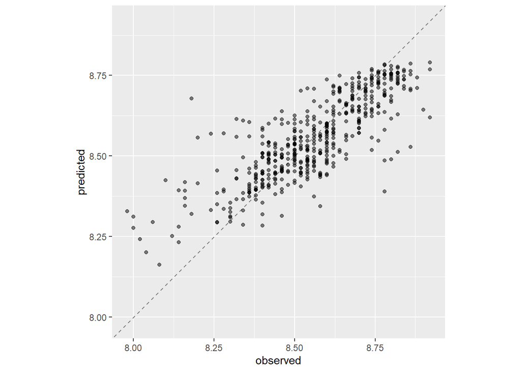

```r
rf_test_results%>%
  collect_predictions()%>%
  ggplot(aes(x = ph, y = .pred))+
  geom_abline(color = 'gray50', lty = 2)+
  geom_point(alpha = .5)+
  coord_obs_pred()+
  labs(x = 'observed', y = 'predicted')
```

Linear Regression

```r
high_corr = findCorrelation(cor(ph_train%>%select(-'brand_code')), names = TRUE)
linear_model = lm(ph~.,ph_train%>%select(-c('brand_code',all_of(high_corr))))
```

PCR

```r
apply_pca = function(pca_model,data){
  pca_data = data.frame(predict(pca_model,data))
  pca_data$ph = data['ph'][[1]]
  return(pca_data)
}
pca_model = prcomp(ph_train%>%select(-c(brand_code,ph)),scale=TRUE)

ph_pca_train = apply_pca(pca_model, ph_train)
pcr_model = lm(ph~.,data = ph_pca_train)
```

Predictions against test data

```r
predictions = data.frame(ph = ph_test$ph)
wkflow_models = race_results$wflow_id

for (model in wkflow_models){
  best_model = race_results%>%
  extract_workflow_set_result(model)%>%
  select_best(metric = 'rmse')
 predictions[model] = race_results%>%
  extract_workflow(model)%>%
  finalize_workflow(best_model)%>%
  fit(ph_train)%>%
  predict(ph_test)
}
predictions$linear_regression = predict(linear_model,ph_test)
predictions$PCR = predict(pcr_model,apply_pca(pca_model,ph_test))

predictions%>%head()
```

```
##     ph    boost       rf SVM_radial nearest_neighbor linear_regression      PCR
## 1 8.50 8.635003 8.599861   8.566188         8.487538          8.655354 8.638479
## 2 8.34 8.470973 8.495883   8.521006         8.478933          8.629985 8.605489
## 3 8.42 8.415807 8.490117   8.386269         8.420386          8.423893 8.406048
## 4 8.40 8.470255 8.496905   8.473017         8.419836          8.549044 8.509634
## 5 8.36 8.472733 8.447204   8.447105         8.418773          8.515768 8.482093
## 6 8.38 8.546646 8.480599   8.537699         8.412661          8.618094 8.584302
```

Based on RMSE, KNN model performed the best on the data

```r
performance = list('model' = c(), 'rmse' = c())
models_used = names(predictions%>%select(-ph))

for (model in models_used){
  rmse = RMSE(predictions['ph'][[1]],predictions[model][[1]])
  performance$model = c(performance$model,model)
  performance$rmse = c(performance$rmse,rmse)
}

performance_df = data.frame(performance)%>%
  arrange(rmse)
performance_df
```

```
##               model       rmse
## 1  nearest_neighbor 0.09933587
## 2                rf 0.10295946
## 3             boost 0.10636273
## 4        SVM_radial 0.13969716
## 5               PCR 0.14347318
## 6 linear_regression 0.14532893
```

```r
knn_model = race_results%>%
  extract_workflow('nearest_neighbor')%>%
  finalize_workflow(best_results_knn)%>%
  fit(ph_train)
```

## Final Prediction

Since KNN performed the best, we will be using that model to predict on the test data

```r
test_data['ph'] = predict(knn_model, test_data)
test_data%>%head()
```

```
##   brand_code carb_volume fill_ounces pc_volume carb_pressure carb_temp   psc
## 1          D    5.480000    24.03333 0.2700000          65.4     134.6 0.236
## 2          A    5.393333    23.95333 0.2266667          63.2     135.0 0.042
## 3          B    5.293333    23.92000 0.3033333          66.4     140.4 0.068
## 4          B    5.266667    23.94000 0.1860000          64.8     139.0 0.004
## 5          B    5.406667    24.20000 0.1600000          69.4     142.2 0.040
## 6          B    5.286667    24.10667 0.2120000          73.4     147.2 0.078
##   psc_fill psc_co2 mnf_flow carb_pressure1 fill_pressure hyd_pressure1
## 1     0.40    0.04     -100          116.6          46.0             0
## 2     0.22    0.08     -100          118.8          46.2             0
## 3     0.10    0.02     -100          120.2          45.8             0
## 4     0.20    0.02     -100          124.8          40.0             0
## 5     0.30    0.06     -100          115.0          51.4             0
## 6     0.22      NA     -100          118.6          46.4             0
##   hyd_pressure2 hyd_pressure3 hyd_pressure4 filler_level filler_speed
```

[output cut: 27 more lines]

```r
write.csv(test_data,'StudentPredictions.csv',row.names = FALSE)
```